# Naive Bayes Classifier-2

```python
%matplotlib inline
import numpy as np
import pandas as pd
import scipy
import sklearn
import matplotlib.pyplot as plt
import seaborn as sns
from wordcloud import WordCloud
```

```python
# Grab and process the raw data.
amazon = pd.read_csv('amazon_cells_labelled.txt', delimiter= '\t', header=None)
amazon.columns = ['message', 'positive']
```

[figure not shown]

```python
# Generate a word cloud image for only positive messages
wordcloud = WordCloud(background_color="green").generate(" ".join(amazon.loc[amazon.positive== 1, 'message']))
plt.figure(figsize=(15,10))
# Display the generated image:
plt.imshow(wordcloud, interpolation='bilinear')
plt.axis("off")

plt.show()
```

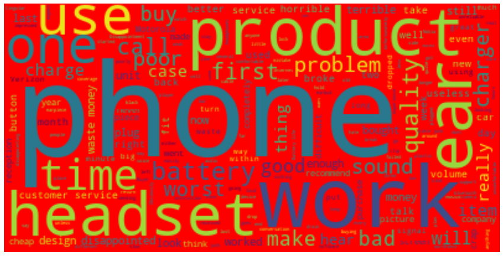

```python
# Generate a word cloud image for only negative messages
wordcloud = WordCloud(background_color="red").generate(" ".join(amazon.loc[amazon.positive== 0, 'message']))
plt.figure(figsize=(15,10))
# Display the generated image:
plt.imshow(wordcloud, interpolation='bilinear')
plt.axis("off")

plt.show()
```

```python
#Use most common words in positive wordcloud (with little overlap in negative wordcloud) as keywords
keywords= ['headset', 'love', 'Motorola', 'good', 'well', 'great', 'easy',
           'Excellent', 'case', 'price', 'winner', 'great', 'free']

for key in keywords:
    amazon[str(key)] = amazon.message.str.contains(
        ' ' + str(key) + ' ',
        case=False
    )
```

```python
#Tool to check how often specific keyword is categorized as positive
amazon.loc[amazon.message.str.contains('best'), 'positive'].sum()/amazon.message.str.contains('best').sum()
```

```
0.8947368421052632
```

```python
amazon.loc[amazon.message.str.contains('easy'), 'positive'].sum()
```

```
11
```

```python
#Transform positive into bool
amazon['positive']= (amazon['positive']== 1)
```

```python
#inspect dataset w/ new changes
amazon.head()
```

|  | message | positive | headset | love | Motorola | good | well | great | easy | Excellent | case | price | winner | free |
| --- | --- | --- | --- | --- | --- | --- | --- | --- | --- | --- | --- | --- | --- | --- |
| 0 | So there is no way for me to plug it in here i... | False | False | False | False | False | False | False | False | False | False | False | False | False |
| 1 | Good case, Excellent value. | True | False | False | False | False | False | False | False | True | False | False | False | False |
| 2 | Great for the jawbone. | True | False | False | False | False | False | False | False | False | False | False | False | False |
| 3 | Tied to charger for conversations lasting more... | False | False | False | False | False | False | False | False | False | False | False | False | False |
| 4 | The mic is great. | True | False | False | False | False | False | False | False | False | False | False | False | False |

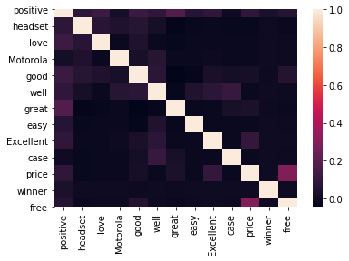

```python
#Check for overlapping correlation of variables
sns.heatmap(amazon.corr())
```

Great! No strong correlations b/w variables means variables are reasonably independent.

```python
#Define data & target for dataset
data= amazon[keywords]
target= amazon['positive']
```

```python
#Check model efficiency
from sklearn.naive_bayes import BernoulliNB

bnb=BernoulliNB()

#Fit model to data
bnb.fit(data, target)

#Classify
predictor= bnb.predict(data)

print("Number of mislabeled points out of a total {} points : {}".format(
    amazon.shape[0],
    (target != predictor).sum()
))
```

```
Number of mislabeled points out of a total 1000 points : 389
```

```python
print('The Amazon model was {}% accurate in detecting positive.'.format((target == predictor).sum()*100/amazon.shape[0]))
```

```
The Amazon model was 61.1% accurate in detecting positive.
```

## Challenge: Evaluate your sentiment classifier

It's time to revisit your classifier from the previous assignment. Using the evaluation techniques we've covered here, look at your classifier's performance in more detail. Then go back and iterate by engineering new features, removing poor features, or tuning parameters. Repeat this process until you have five different versions of your classifier. Once you've iterated, answer these questions to compare the performance of each:

Do any of your classifiers seem to overfit?

Which seem to perform the best? Why?

Which features seemed to be most impactful to performance?

Write up your iterations and answers to the above questions in a few pages. Submit a link below and go over it with your mentor to see if they have any other ideas on how you could improve your classifier's performance.

```python
print('Accuracy of a blind guess for negative sentiment: {}%'.format(100*(amazon['positive']== False).sum()/amazon.shape[0]))
print('Accuracy of a blind guess for positive sentiment: {}%'.format(100*(amazon['positive']== True).sum()/amazon.shape[0]))
```

```
Accuracy of a blind guess for negative sentiment: 50.0%
Accuracy of a blind guess for positive sentiment: 50.0%
```

```python
from sklearn.metrics import confusion_matrix
conmat= confusion_matrix(target, predictor)
print(conmat)
```

```
[[473  27]
 [362 138]]
```

```python
print('Version 1 Overall Accuracy: {}%'.format(100*(conmat[0,0]+conmat[1,1])/amazon.shape[0]))
print('Model Accuracy of negative predictions: {}%'.format(100*conmat[0,0]/(conmat[0,0]+conmat[0,1])))
print('Model Accuracy of positive predictions: {}%'.format(100*conmat[1,1]/(conmat[1,1]+conmat[1,0])))
```

```
Version 1 Overall Accuracy: 61.1%
Model Accuracy of negative predictions: 94.6%
Model Accuracy of positive predictions: 27.6%
```

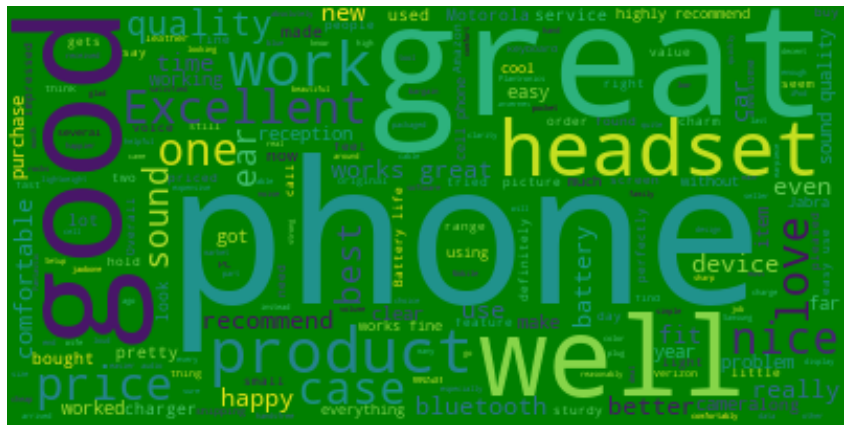

```python
# Generate a word cloud image for only positive messages
wordcloud = WordCloud(background_color="green").generate(" ".join(amazon.loc[amazon.positive== 1, 'message']))
plt.figure(figsize=(15,10))
# Display the generated image:
plt.imshow(wordcloud, interpolation='bilinear')
plt.axis("off")

plt.show()
```

```python
#Version 2
keywords2= ['headset', 'love', 'good', 'well', 'great', 'happy',
           'Excellent', 'case', 'price', 'great', 'free', 'easy',
           'recommend', 'new service', 'best', 'bluetooth']

for key in keywords2:
    amazon[str(key)] = amazon.message.str.contains(
        ' ' + str(key) + ' ',
        case=False
    )
```

```python
#Define data & target for dataset
data2= amazon[keywords2]
target2= amazon['positive']
```

```python
#Check model efficiency
#Fit model to data
bnb.fit(data2, target2)

#Classify
predictor= bnb.predict(data2)

print("Number of mislabeled points out of a total {} points : {}".format(
    amazon.shape[0],
    (target != predictor).sum()
))
```

```
Number of mislabeled points out of a total 1000 points : 362
```

```python
conmat2= confusion_matrix(target, predictor)
print(conmat2)
```

```
[[463  37]
 [325 175]]
```

```python
print('Version 2 Overall accuracy: {}%'.format(100*(conmat2[0,0]+conmat2[1,1])/amazon.shape[0]))
print('Model Accuracy of negative predictions: {}%'.format(100*conmat2[0,0]/(conmat2[0,0]+conmat2[0,1])))
print('Model Accuracy of positive predictions: {}%'.format(100*conmat2[1,1]/(conmat2[1,1]+conmat2[1,0])))
```

```
Version 2 Overall accuracy: 63.8%
Model Accuracy of negative predictions: 92.6%
Model Accuracy of positive predictions: 35.0%
```

```python
#Version 3
keywords3= ['love', 'really', 'good', 'well', 'great', 'comfortable',
           'Excellent', 'case', 'price', 'great', 'winner', 'purchase',
           'recommend', 'ear', 'new service', 'best', 'bluetooth']

for key in keywords3:
    amazon[str(key)] = amazon.message.str.contains(
        ' ' + str(key) + ' ',
        case=False
    )
```

```python
#Define data & target for dataset
data3= amazon[keywords3]
target= amazon['positive']
```

```python
#Check model efficiency
#Fit model to data
bnb.fit(data3, target)

#Classify
predictor= bnb.predict(data3)

print("Number of mislabeled points out of a total {} points: {}".format(
    amazon.shape[0],
    (target != predictor).sum()
))
```

```
Number of mislabeled points out of a total 1000 points: 375
```

```python
conmat3= confusion_matrix(target, predictor)
print(conmat3)
```

```
[[471  29]
 [346 154]]
```

```python
print('Version 3 Overall Accuracy: {}%'.format(100*(conmat3[0,0] + conmat3[1,1])/amazon.shape[0]))
print('Model Accuracy of negative predictions: {}%'.format(100*conmat3[0,0]/(conmat3[0,0]+conmat3[0,1])))
print('Model Accuracy of positive predictions: {}%'.format(100*conmat3[1,1]/(conmat3[1,1]+conmat3[1,0])))
```

```
Version 3 Overall Accuracy: 62.5%
Model Accuracy of negative predictions: 94.2%
Model Accuracy of positive predictions: 30.8%
```

```python
#Version 4
keywords4= ['good', 'love', 'well', 'happy', 'comfortable',
           'Excellent', 'case', 'price', 'great', 'purchase', 'worked',
           'highly recommend', 'free', 'new']

for key in keywords4:
    amazon[str(key)] = amazon.message.str.contains(
        ' ' + str(key) + ' ',
        case=False
    )
```

```python
#Define data & target for dataset
data4= amazon[keywords4]
target= amazon['positive']
```

```python
#Check model efficiency
#Fit model to data
bnb.fit(data4, target)

#Classify
predictor= bnb.predict(data4)

print("Number of mislabeled points out of a total {} points : {}".format(
    amazon.shape[0],
    (target != predictor).sum()
))
```

```
Number of mislabeled points out of a total 1000 points : 385
```

```python
conmat4= confusion_matrix(target, predictor)
print(conmat4)
```

```
[[474  26]
 [359 141]]
```

```python
print('Version 4 Overall Accuracy: {}%'.format(100*(conmat4[0,0]+conmat4[1,1])/amazon.shape[0]))
print('Model Accuracy of negative predictions: {}%'.format(100*conmat4[0,0]/(conmat4[0,0]+conmat4[0,1])))
print('Model Accuracy of positive predictions: {}%'.format(100*conmat4[1,1]/(conmat4[1,1]+conmat4[1,0])))
```

```
Version 4 Overall Accuracy: 61.5%
Model Accuracy of negative predictions: 94.8%
Model Accuracy of positive predictions: 28.2%
```

```python
#Version 5
keywords5= ['love', 'good', 'well', 'happy', 'comfortable','Excellent', 'fine',
            'excellent', 'case', 'works great', 'price', 'great', 'purchase', 'recommend',
            'worked', 'highly recommend', 'sound quality', 'free', 'new', 'bluetooth']

for key in keywords5:
    amazon[str(key)] = amazon.message.str.contains(
        ' ' + str(key) + ' ',
        case=False
    )
```

```python
#Define data & target for dataset
data5= amazon[keywords5]
target= amazon['positive']
```

```python
#Check model efficiency
#Fit model to data
bnb.fit(data5, target)

#Classify
predictor= bnb.predict(data5)

print("Number of mislabeled points out of a total {} points : {}".format(
    amazon.shape[0],
    (target != predictor).sum()
))
```

```
Number of mislabeled points out of a total 1000 points : 373
```

```python
conmat5= confusion_matrix(target, predictor)
print(conmat5)
```

```
[[465  35]
 [338 162]]
```

```python
print('Version 5 Overall Accuracy: {}%'.format(100*(conmat5[0,0]+conmat5[1,1])/amazon.shape[0]))
print('Specificity score: {}%'.format(100*conmat5[0,0]/(conmat5[0,0]+conmat5[0,1])))
print('Sensitivity score: {}%'.format(100*conmat5[1,1]/(conmat5[1,1]+conmat5[1,0])))
```

```
Version 5 Overall Accuracy: 62.7%
Specificity score: 93.0%
Sensitivity score: 32.4%
```

```python
#Tool to check how often specific keyword is categorized as positive
amazon.loc[amazon.message.str.contains('purchase'), 'positive'].sum()/amazon.message.str.contains('purchase').sum()
```

```
0.7058823529411765
```

```python
amazon.loc[amazon.message.str.contains('purchase'), 'positive'].sum()
```

```
12
```

```python
#import IMDB data for further testing
imdb = pd.read_csv('imdb_labelled.txt', delimiter= '\t', header=None)
imdb.columns = ['message', 'spam']
```

```python
#Create bool columns for each keyword
for key in keywords2:
    imdb[str(key)] = imdb.message.str.contains(
        ' ' + str(key) + ' ',
        case=False
    )
```

```python
#Transform spam into bool
imdb['spam']= (imdb['spam']== 1)
```

```python
#Redefine data & target for new dataset
data= imdb[keywords2]
target=imdb['spam']
bnb=BernoulliNB()

#Fit model to data
bnb.fit(data, target)

#Classify
predictor= bnb.predict(data)
target= imdb['spam']

print("Number of mislabeled points out of a total {} points : {}".format(
    imdb.shape[0],
    (target != predictor).sum()
))
```

```
Number of mislabeled points out of a total 748 points : 329
```

```python
print('The Amazon model was {}% accurate in detecting positive sentiments in the IMDB dataset.'.format((target == predictor).sum()*100/imdb.shape[0]))
```

```
The Amazon model was 56.01604278074866% accurate in detecting positive sentiments in the IMDB dataset.
```

```python
#Conduct overfit experiment
from sklearn.model_selection import train_test_split
# Use train_test_split to create the necessary training and test groups
X_train, X_test, y_train, y_test = train_test_split(data2, target2, test_size=0.2, random_state=20)
print('With 20% Holdout: ' + str(bnb.fit(X_train, y_train).score(X_test, y_test)))
print('Testing on Sample: ' + str(bnb.fit(data2, target2).score(data2, target2)))
```

```
With 20% Holdout: 0.625
Testing on Sample: 0.638
```